# Should We Be Going to Schools with Bad Food?

Chase Williamson and Tiffany Wang

Spring 2018

## Mini-Project 2: Data Wrangling

We’re sure many of you have heard of Malcolm Gladwell, a famous pop social scientist who has written multiple books and now hosts a podcast called Revisionist History. In its first season, Gladwell aired an episode named [Food Fight](http://revisionisthistory.com/episodes/05-food-fight), highlighting the relationship between college endowment, money spent on food services, and number of low-income students at higher education instutions by comparing Vassar to Bowdoin. He argues that while Vassar cannot offer the luxury goods like hiring a chef to design delicious meals, its commitment to admitting low income students and making their education affordable is much more important and worth the sacrifice in terms of food quality.

While the contrast between Vassar and Bowdoin certainly provides evidence for a compelling narrative, it is important to look at the data to see if this is a trend across all institutions. Surely, it is possible to succeed on both fronts. We took a list of the [50 colleges](https://www.bestvalueschools.com/rankings/college-dining-halls/) with the best food in 2017 to compare them with various school stats from the U.S. Department of Education’s [College Scorecard](https://collegescorecard.ed.gov/data/documentation/) data to verify Gladwell’s claim.

We first scrape the list of 50 colleges with the best food in the country from the Best Value Schools website using the rvest package.

```r
#Load packages
library(dplyr)
library(httr)
library(rvest)
library(tidyr)


#Assign url containing college food rankings to url.food
url.food <- "https://www.bestvalueschools.com/rankings/college-dining-halls/"

#Scrape food rankings from url
good.foods <- url.food %>%
  read_html() %>%
  html_nodes(css = "h3") %>%
  html_text()

good.foods
```

```
##  [1] "The 50 Colleges with the Best Food Ranking Methodology"
##  [2] "50. University of Chicago"
##  [3] "49. College of William and Mary"
##  [4] "48. California Baptist University"
##  [5] "47. Roger Williams University"
##  [6] "46. University of Houston"
##  [7] "45. Muhlenberg College"
##  [8] "44. Princeton University"
##  [9] "43. University of Oregon"
## [10] "42. Columbia University in the City of New York"
## [11] "41. Northwestern University"
## [12] "40. University of South Carolina-Columbia"
## [13] "39. Kent State University-Kent"
## [14] "38. College of the Atlantic"
## [15] "37. University of San Diego"
```

[output cut: 36 more lines]

```r
#Convert text object that we scraped to a dataframe with two columns: rank and school name
good.foods <- as.data.frame(good.foods) %>%
  filter(good.foods != "The 50 Colleges with the Best Food Ranking Methodology") %>%
  separate(col = good.foods,
           into = c("food_rank", "school"),
           extra = "merge")
```

Now we downloaded the information from the College Scorecard. They have A LOT of data, so we chose a few specific variables to analyze: -ownership of institution (public, private nonprofit, private for-profit) -percent of students who receive a Pell Grant -percent of first generation students -cost of institution (separate variables for public and private) There was only data available up to 2015, so we grabbed that, assuming that the food didn’t change drastically between then and now.

```r
#Downloading the package to help load the data.
library(rscorecard)
#We have to use a key so that the government knows who's using their data
my_key <- "1HADPASnygYXC2p1ZxFMAN7j2VnS9IFDdvDMKZTW"
url <- "https://api.data.gov/ed/collegescorecard/v1/schools?"
scrape_scorecard <- GET(url, query = list(api_key = my_key))
sc_key(my_key)
```

```
## DATAGOV_API_KEY environment variable now set. You may now use sc_get() without specifying a key.
```

```r
dat <- sc_init() %>%
  sc_select(control, pctpell, PAR_ED_PCT_1STGEN, instnm, npt4_pub, npt4_priv) %>%
  sc_year(2015) %>%
  sc_get()
```

[output not shown]

[output not shown]

[output not shown]

[output not shown]

[output not shown]

[output not shown]

[output not shown]

[output not shown]

[output not shown]

[output not shown]

[output not shown]

[output not shown]

[output not shown]

[output not shown]

[output not shown]

[output not shown]

[output not shown]

[output not shown]

[output not shown]

[output not shown]

[output not shown]

[output not shown]

[output not shown]

[output not shown]

[output not shown]

[output not shown]

[output not shown]

[output not shown]

[output not shown]

[output not shown]

[output not shown]

[output not shown]

[output not shown]

[output not shown]

[output not shown]

[output not shown]

[output not shown]

[output not shown]

[output not shown]

[output not shown]

[output not shown]

[output not shown]

[output not shown]

[output not shown]

[output not shown]

[output not shown]

[output not shown]

[output not shown]

[output not shown]

[output not shown]

[output not shown]

[output not shown]

[output not shown]

[output not shown]

[output not shown]

[output not shown]

[output not shown]

[output not shown]

[output not shown]

[output not shown]

[output not shown]

[output not shown]

[output not shown]

[output not shown]

[output not shown]

[output not shown]

[output not shown]

[output not shown]

[output not shown]

[output not shown]

[output not shown]

[output not shown]

[output not shown]

[output not shown]

[output not shown]

[output not shown]

[output not shown]

```r
#Combining the two variables of cost of public and private institutions
dat <-  gather(dat, npt4_pub, npt4_priv, key = "Type of School", value = "Cost")
```

Now we merged the two datasets so that we can visually compare the different variables regarding money with the quality of food.

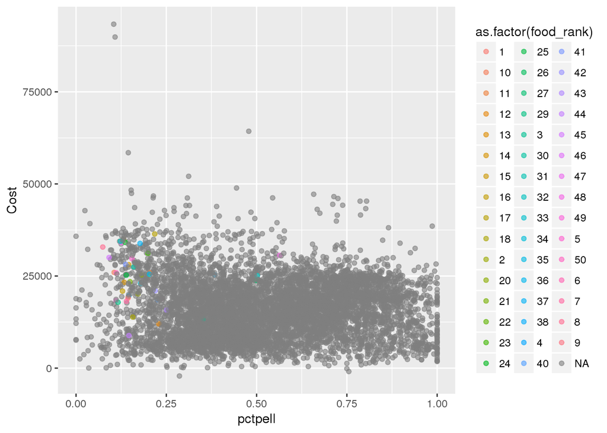

```r
colleges_food <- left_join(dat, good.foods, by = c("instnm" = "school"))

#Downloading ggplot to make plots.
library(ggplot2)
ggplot(colleges_food, aes(x = pctpell, y = Cost, color = as.factor(food_rank))) +
  geom_point(alpha = .6)
```

Obviously, cost, and definitely not food ranking, is not the only factor that goes into your choice of college. We also wanted to look at the school ranking to see if this phenomenon is apparent with top-ranked schools. We gathered information from [Forbes’](https://en.wikipedia.org/wiki/Forbes_Magazine%27s_List_of_America%27s_Best_Colleges) list of “America’s Best Colleges” in 2017 and then merged this new dataset to our previously existing one.

```r
#Assign url containing college rankings to url.rank
url.rank <- "https://en.wikipedia.org/wiki/Forbes_Magazine%27s_List_of_America%27s_Best_Colleges"

#Scrape Forbes college rankings from wikipedia
forbes.top25 <- url.rank %>%
  read_html() %>%
  html_nodes(css = "li") %>%
  html_text()

#Remove extraneous material
forbes.top25 <- as.data.frame(forbes.top25[c(1:25)])

#Create column containing college ranks. Note: that the colleges are in ranked order, but there is not a rank variable
forbes.top25$forbes_rank <- seq.int(nrow(forbes.top25))

#Label columns
colnames(forbes.top25) <- c("school", "forbes_rank")

#Merge college scorecard + food ranking data with college ranking data
colleges_food_rank <- left_join(colleges_food,
                                forbes.top25,
                                by = c("instnm" = "school"))
#Create "food_ranked" and "forbes_ranked" dummy variable indicating if the variable is labeled in that particular category
colleges_food_rank <- colleges_food_rank %>%
  mutate(food_rank = as.numeric(food_rank),
         forbes_rank = as.numeric(forbes_rank)) %>%
  mutate(food_ranked = as.numeric(!is.na(food_rank)),
         forbes_ranked = as.numeric(!is.na(forbes_rank)))
```

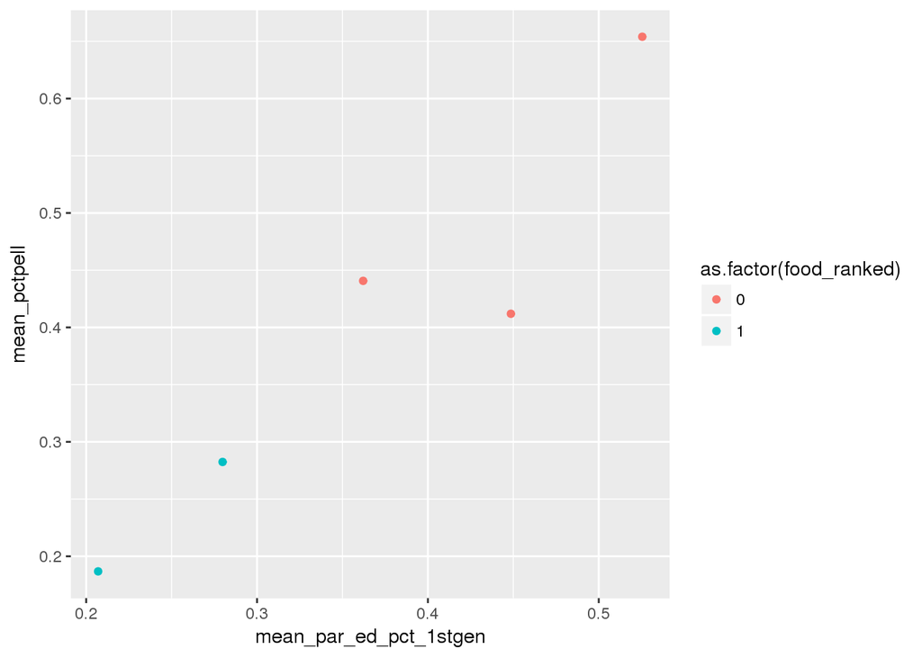

```r
#What if we just look at school categories?
private_food <- colleges_food_rank %>%
  filter(!is.na(pctpell), !is.na(par_ed_pct_1stgen)) %>%
  group_by(control, food_ranked) %>%
  summarise(mean_pctpell = mean(pctpell),
            mean_par_ed_pct_1stgen = mean(par_ed_pct_1stgen))

ggplot(private_food, aes(x = mean_par_ed_pct_1stgen, y = mean_pctpell, color = as.factor(food_ranked))) +
  geom_point()
```

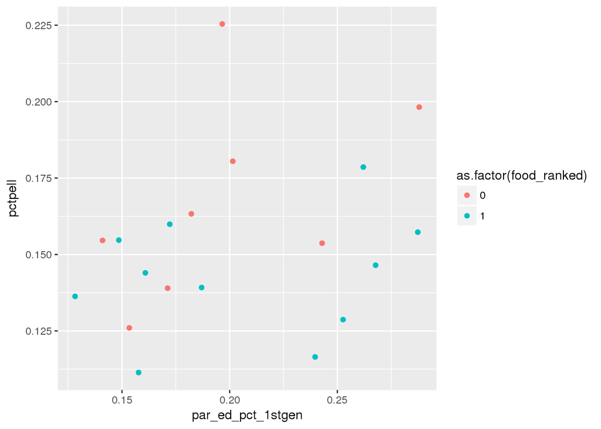

```r
#What if we only look at schools that are ranked in the top 25 by forbes?
forbes_ranked_only <- filter(colleges_food_rank, forbes_ranked==1)
ggplot(forbes_ranked_only, aes(x = par_ed_pct_1stgen, y = pctpell, color = as.factor(food_ranked))) +
  geom_point()
```

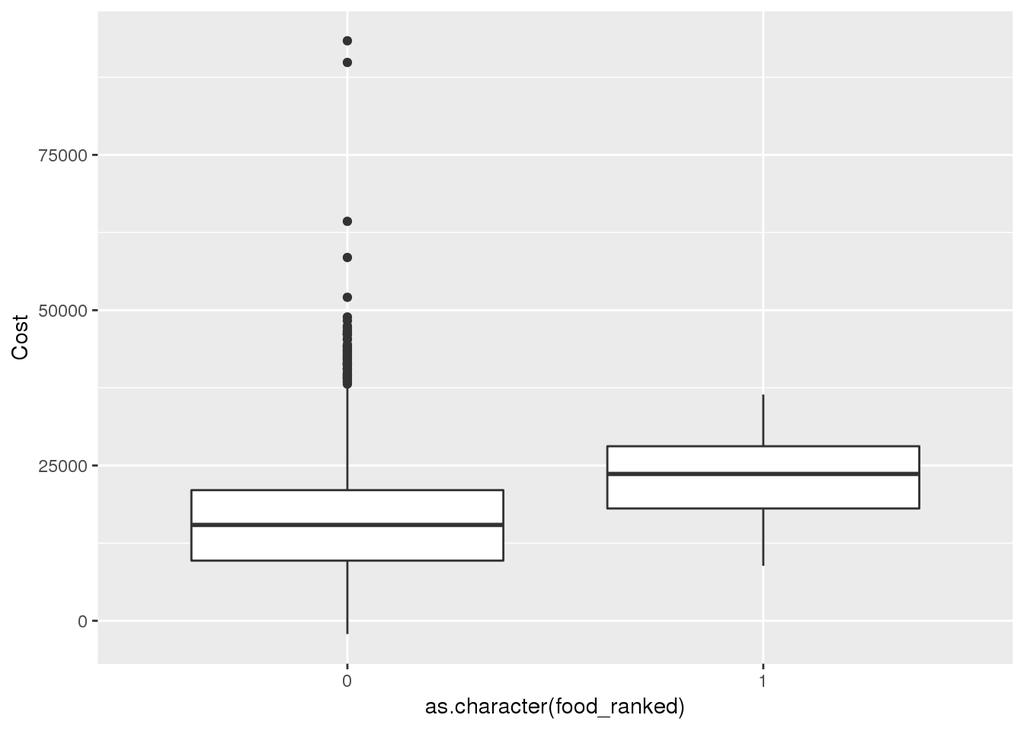

```r
#Does the cost of the school have to do with the quality of food?
ggplot(colleges_food_rank, aes(x = as.character(food_ranked), y = Cost)) +
  geom_boxplot()
```

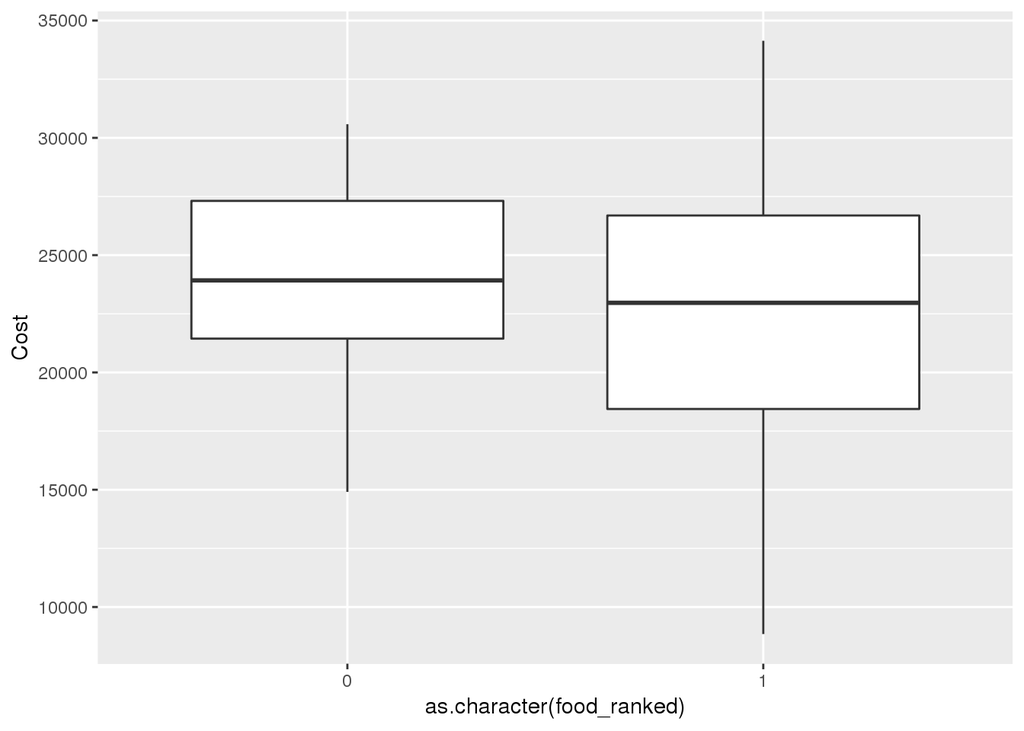

```r
#But how about when we just take the "good" schools?
ggplot(forbes_ranked_only, aes(x = as.character(food_ranked), y = Cost)) +
  geom_boxplot()
```